# Dementia case

# 1 Description of DataSchema variable

The description of harmonised variable is the following:

- Short name: `dementia`
- Variable label: `Any type of dementia case`
- Variable description: `Any type of dementia case (self-reported or based on neuropsychologic exploration)`
- Domain: `Psycological measures`
- Value type: `Categorical`
- Category coding:

| **Code** | **Category Label** |
| --- | --- |
| 0 | no dementia |
| 1 | dementia |

- Category missings:

| **Code** | **Category Label** |
| --- | --- |
| 991 | CAPI/interviewer error |
| 992 | Impute |
| 993 | Disable to measure |
| 994 | Not attempt/not done |
| 995 | Does not answer |
| 996 | Not applicable |
| 997 | Refuse |
| 998 | Do not know |
| 999 | Missing |

# 2 Data process

## 2.1 England

### 2.1.1 Wave 1

#### 2.1.1.1 Study-specific variable description

| **Name** | `hedibde` |
| --- | --- |
| **Label** | `Ever reported dementia or memory impairment (diagnosed)` |
| **Table name** | `wave_3_elsa_data_v4` |
| **Categories** | `0 = Not in any wave` `1 = By Wave 1` `2 = By Wave 2` `By Wave 3` |
| **Missing** | `-1 = In Wave 1 only and did not report` `In Wave 2 only and did not report` `In Wave 3 only and did not report` |
| **Description** |  |

(en) (D) Ever reported dementia or memory impairment (diagnosed)

| Sample size | Missing values |
| --- | --- |
| 12099 | 4123 |

Category

|  | 0 | 1 | 2 | 3 |
| --- | --- | --- | --- | --- |
| Frequency | 7869.00 | 27.00 | 26.00 | 54.00 |
| Percentage | 65.04 | 0.22 | 0.21 | 0.45 |

Type of missing

|  | -1 | -2 | -3 | NA |
| --- | --- | --- | --- | --- |
| Frequency | 0 | 0 | 0 | 4123.00 |
| Percentage | 0 | 0 | 0 | 34.08 |

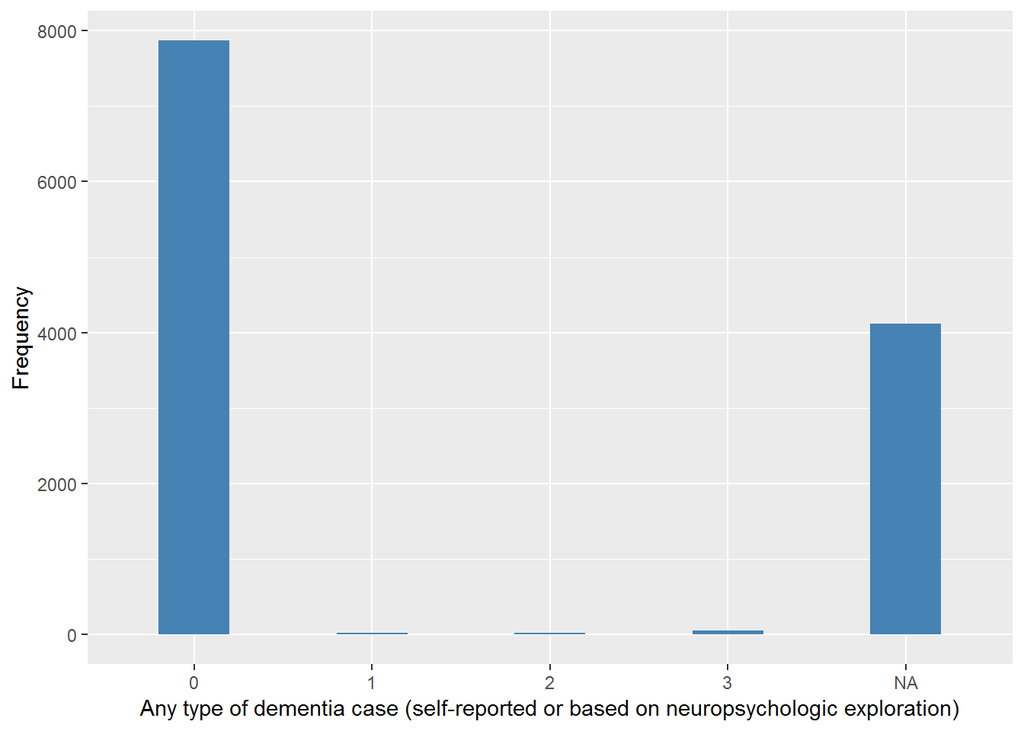

#### 2.1.1.2 Harmonisation algorithm

To compute the harmonized variable from the study-specific variable it has to be recoded as follows:

- `0,2,3 into 0`
- `1 into 1`
- `-1,-2,-3 into 999`

**R script:**

```r
ELSA_ds_w1 <- tibble(id = ELSA_dem$id)
ELSA_ds_w1$dementia <- car::recode(ELSA_dem[[2]], "2=0; 3=0; -1=999; -2=999; -3=999; NA=999")
```

#### 2.1.1.3 Statistical description of the new harmonised variable

Any type of dementia case (self-reported or based on neuropsychologic exploration)

| Sample size | Missing values |
| --- | --- |
| 12099 | 4123 |

Category

|  | 0 | 1 |
| --- | --- | --- |
| Frequency | 7949.0 | 27.00 |
| Percentage | 65.7 | 0.22 |

Type of missing

|  | 991 | 992 | 993 | 994 | 995 | 996 | 997 | 998 | 999 | NA |
| --- | --- | --- | --- | --- | --- | --- | --- | --- | --- | --- |
| Frequency | 0 | 0 | 0 | 0 | 0 | 0 | 0 | 0 | 4123.00 | 0 |
| Percentage | 0 | 0 | 0 | 0 | 0 | 0 | 0 | 0 | 34.08 | 0 |

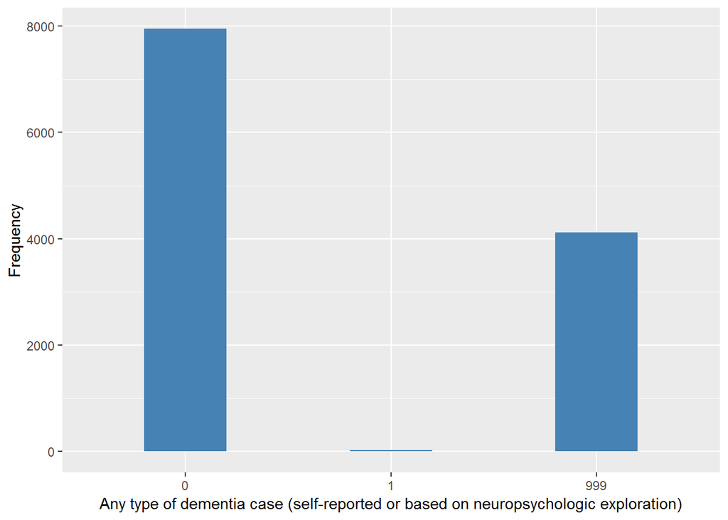

#### 2.1.1.4 Validation

### 2.1.2 Wave 2

#### 2.1.2.1 Study-specific variable description

| **Name** | `hedibde` |
| --- | --- |
| **Label** | `Ever reported dementia or memory impairment (diagnosed)` |
| **Table name** | `wave_3_elsa_data_v4` |
| **Categories** | `0 = Not in any wave` `1 = By Wave 1` `2 = By Wave 2` `By Wave 3` |
| **Missing** | `-1 = In Wave 1 only and did not report` `In Wave 2 only and did not report` `In Wave 3 only and did not report` |
| **Description** |  |

(en) (D) Ever reported dementia or memory impairment (diagnosed)

| Sample size | Missing values |
| --- | --- |
| 9432 | 1752 |

Category

|  | 0 | 1 | 2 | 3 |
| --- | --- | --- | --- | --- |
| Frequency | 7589.00 | 24.00 | 27.00 | 40.00 |
| Percentage | 80.46 | 0.25 | 0.29 | 0.42 |

Type of missing

|  | -1 | -2 | -3 | NA |
| --- | --- | --- | --- | --- |
| Frequency | 0 | 0 | 0 | 1752.00 |
| Percentage | 0 | 0 | 0 | 18.58 |

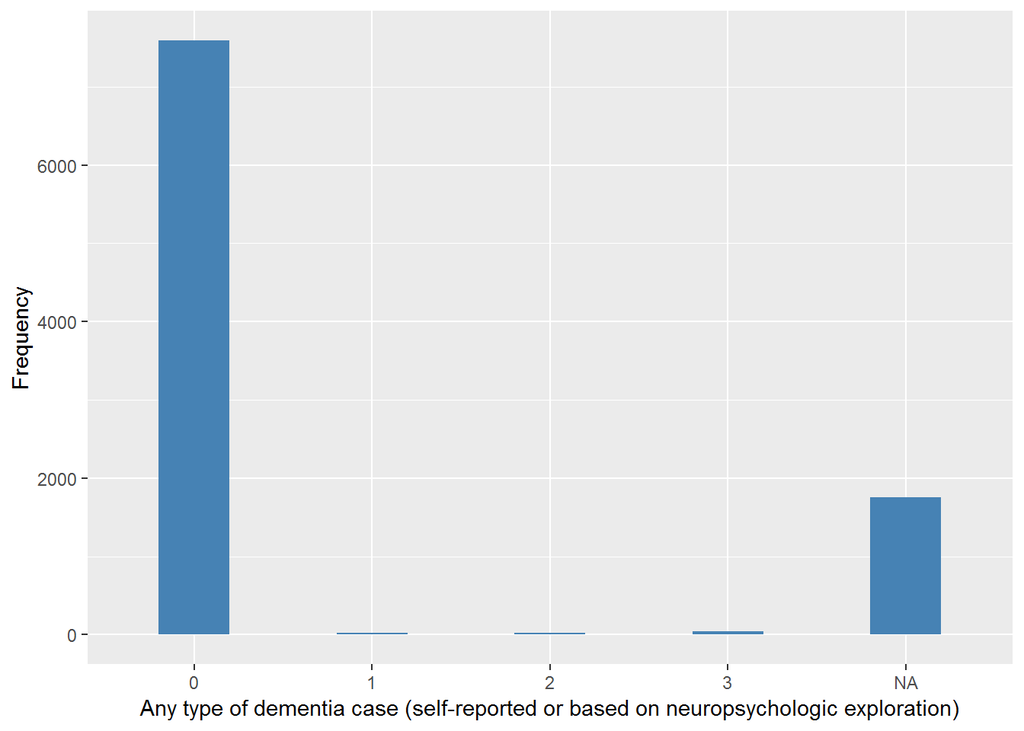

#### 2.1.2.2 Harmonisation algorithm

To compute the harmonized variable from the study-specific variable it has to be recoded as follows:

- `0,3 into 0`
- `1,2 into 1`
- `-1,-2,-3 into 999`

**R script:**

```r
ELSA_ds_w2 <- tibble(id = ELSA_dem$id)
ELSA_ds_w2$dementia <- car::recode(ELSA_dem[[2]], "2=1; 3=0; -1=999; -2=999; -3=999; NA=999")
```

#### 2.1.2.3 Statistical description of the new harmonised variable

Any type of dementia case (self-reported or based on neuropsychologic exploration)

| Sample size | Missing values |
| --- | --- |
| 9432 | 1752 |

Category

|  | 0 | 1 |
| --- | --- | --- |
| Frequency | 7629.00 | 51.00 |
| Percentage | 80.88 | 0.54 |

Type of missing

|  | 991 | 992 | 993 | 994 | 995 | 996 | 997 | 998 | 999 | NA |
| --- | --- | --- | --- | --- | --- | --- | --- | --- | --- | --- |
| Frequency | 0 | 0 | 0 | 0 | 0 | 0 | 0 | 0 | 1752.00 | 0 |
| Percentage | 0 | 0 | 0 | 0 | 0 | 0 | 0 | 0 | 18.58 | 0 |

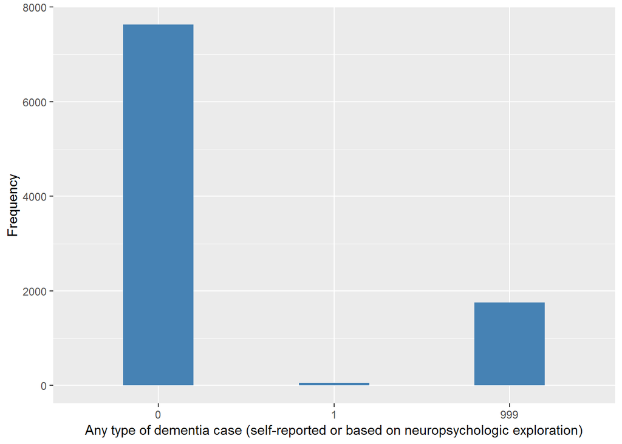

### 2.1.3 Wave 3

#### 2.1.3.1 Study-specific variable description

| **Name** | `hedibde` |
| --- | --- |
| **Label** | `Ever reported dementia or memory impairment (diagnosed)` |
| **Table name** | `wave_3_elsa_data_v4` |
| **Categories** | `0 = Not in any wave` `1 = By Wave 1` `2 = By Wave 2` `By Wave 3` |
| **Missing** | `-1 = In Wave 1 only and did not report` `In Wave 2 only and did not report` `In Wave 3 only and did not report` |
| **Description** |  |

(en) (D) Ever reported dementia or memory impairment (diagnosed)

| Sample size | Missing values |
| --- | --- |
| 9771 | 1725 |

Category

|  | 0 | 1 | 2 | 3 |
| --- | --- | --- | --- | --- |
| Frequency | 7934.0 | 27.00 | 27.00 | 58.00 |
| Percentage | 81.2 | 0.28 | 0.28 | 0.59 |

Type of missing

|  | -1 | -2 | -3 | NA |
| --- | --- | --- | --- | --- |
| Frequency | 0 | 0 | 1725.00 | 0 |
| Percentage | 0 | 0 | 17.65 | 0 |

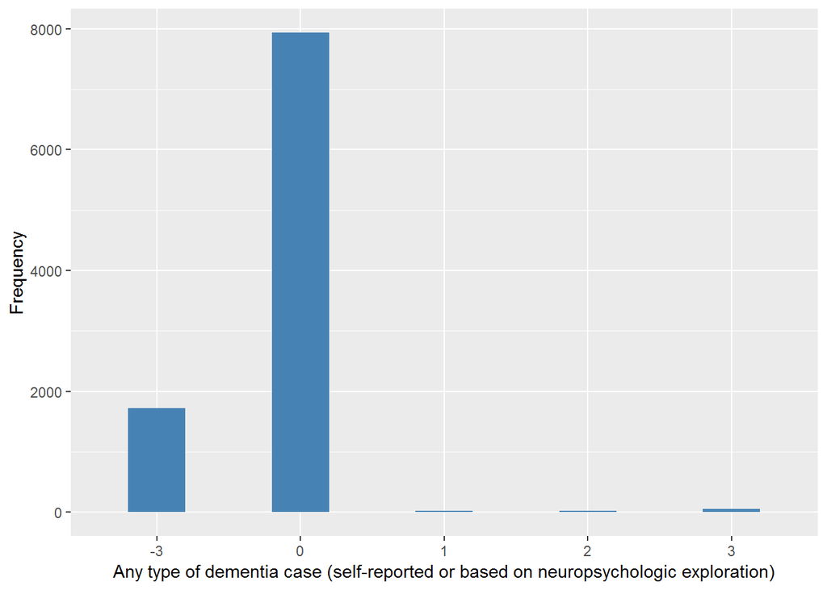

#### 2.1.3.2 Harmonisation algorithm

To compute the harmonized variable from the study-specific variable it has to be recoded as follows:

- `0 into 0`
- `1,2,3 into 1`
- `-1,-2,-3 into 999`

**R script:**

```r
ELSA_ds_w3 <- tibble(id = ELSA_dem$id)
ELSA_ds_w3$dementia <- car::recode(ELSA_dem[[2]], "2=1; 3=1; -1=999; -2=999; -3=999; NA=999")
```

#### 2.1.3.3 Statistical description of the new harmonised variable

Any type of dementia case (self-reported or based on neuropsychologic exploration)

| Sample size | Missing values |
| --- | --- |
| 9771 | 1725 |

Category

|  | 0 | 1 |
| --- | --- | --- |
| Frequency | 7934.0 | 112.00 |
| Percentage | 81.2 | 1.15 |

Type of missing

|  | 991 | 992 | 993 | 994 | 995 | 996 | 997 | 998 | 999 | NA |
| --- | --- | --- | --- | --- | --- | --- | --- | --- | --- | --- |
| Frequency | 0 | 0 | 0 | 0 | 0 | 0 | 0 | 0 | 1725.00 | 0 |
| Percentage | 0 | 0 | 0 | 0 | 0 | 0 | 0 | 0 | 17.65 | 0 |

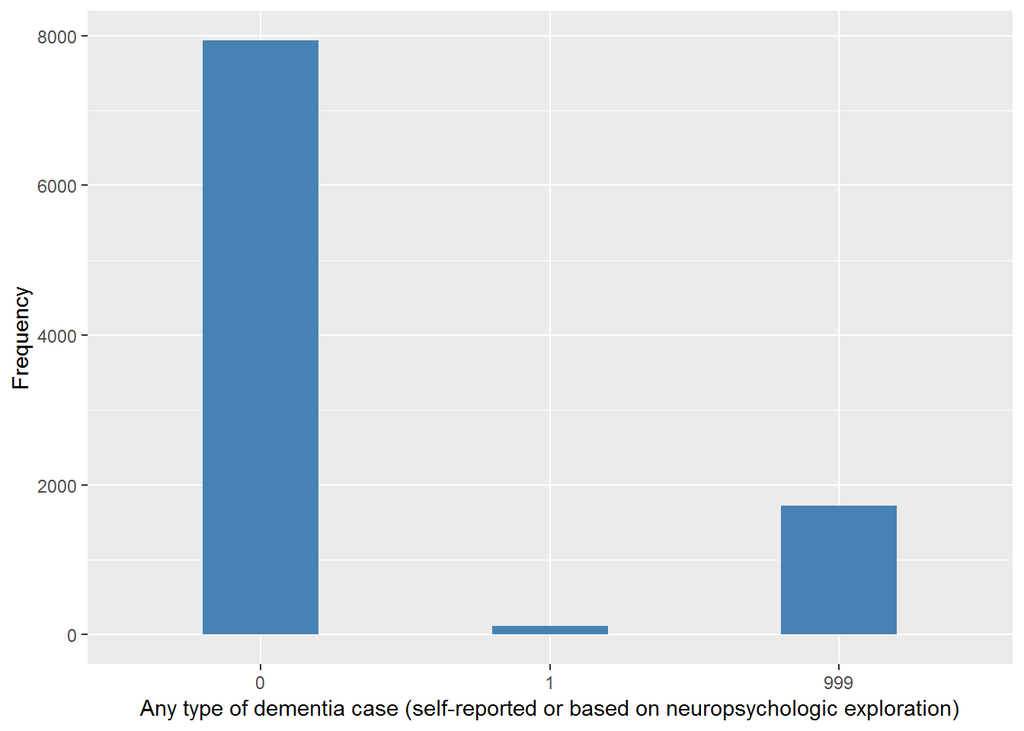

#### 2.1.3.4 Validation

### 2.1.4 Wave 4

#### 2.1.4.1 Study-specific variable description

| **Name** | `HeBdiaDE` |
| --- | --- |
| **Label** | `Wave when diagnosis of dementia or memory impairment was first reported` |
| **Table name** | `wave_4_elsa_data_v3` |
| **Categories** | `0 = Never reported` `1 = Wave 1` `2 = Wave 2` `3 = Wave 3` `4 = Wave 4` |
| **Missing** | `-9 = Refusal` `-8 = Don't know` |
| **Description** |  |

(en) (D) Wave when diagnosis of dementia or memory impairment was first reported

| Sample size | Missing values |
| --- | --- |
| 11050 | 0 |

Category

|  | -9 | -8 | 0 | 1 | 2 | 3 | 4 |
| --- | --- | --- | --- | --- | --- | --- | --- |
| Frequency | 5.00 | 8.00 | 10895.0 | 19.00 | 15.00 | 25.00 | 83.00 |
| Percentage | 0.05 | 0.07 | 98.6 | 0.17 | 0.14 | 0.23 | 0.75 |

Type of missing

|  | -1 | -2 | -3 | NA |
| --- | --- | --- | --- | --- |
| Frequency | 0 | 0 | 0 | 0 |
| Percentage | 0 | 0 | 0 | 0 |

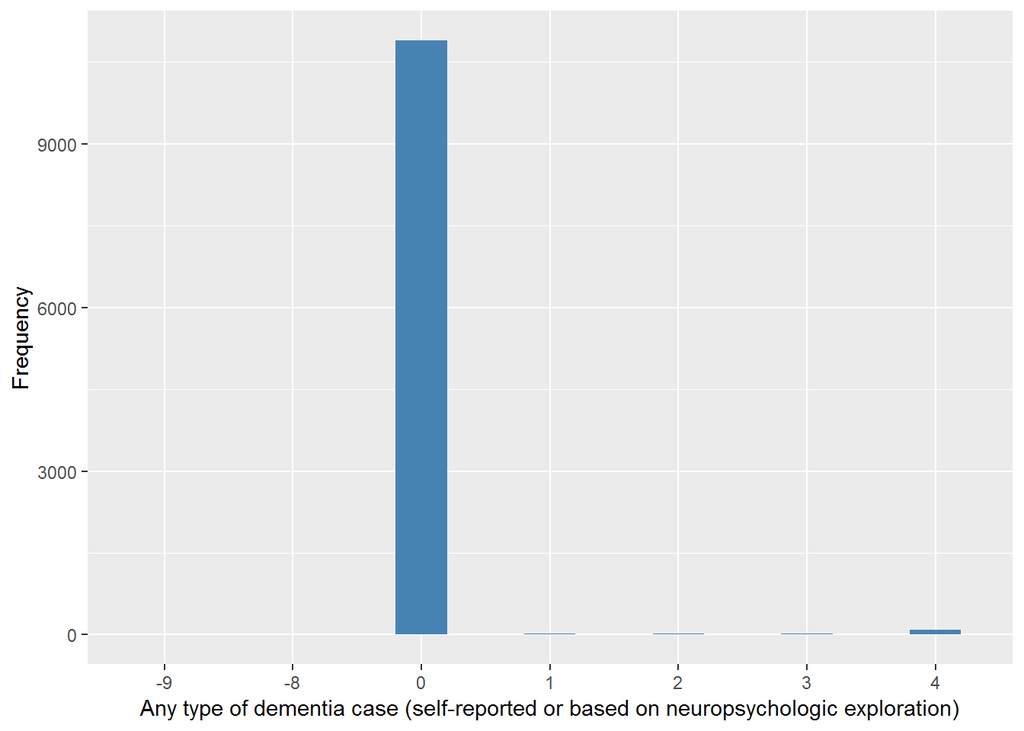

#### 2.1.4.2 Harmonisation algorithm

To compute the harmonized variable from the study-specific variable it has to be recoded as follows:

- `0 into 0`
- `1,2,3,4 into 1`
- `-8 into 998`
- `-9 into 997`

**R script:**

```r
ELSA_ds_w4 <- tibble(id = ELSA_dem$id)
ELSA_ds_w4$dementia <- car::recode(ELSA_dem[[2]], "2=1; 3=1; 4=1; -8=998; -9=997; NA=999")
```

#### 2.1.4.3 Statistical description of the new harmonised variable

Any type of dementia case (self-reported or based on neuropsychologic exploration)

| Sample size | Missing values |
| --- | --- |
| 11050 | 13 |

Category

|  | 0 | 1 |
| --- | --- | --- |
| Frequency | 10895.0 | 142.00 |
| Percentage | 98.6 | 1.29 |

Type of missing

|  | 991 | 992 | 993 | 994 | 995 | 996 | 997 | 998 | 999 | NA |
| --- | --- | --- | --- | --- | --- | --- | --- | --- | --- | --- |
| Frequency | 0 | 0 | 0 | 0 | 0 | 0 | 5.00 | 8.00 | 0 | 0 |
| Percentage | 0 | 0 | 0 | 0 | 0 | 0 | 0.05 | 0.07 | 0 | 0 |

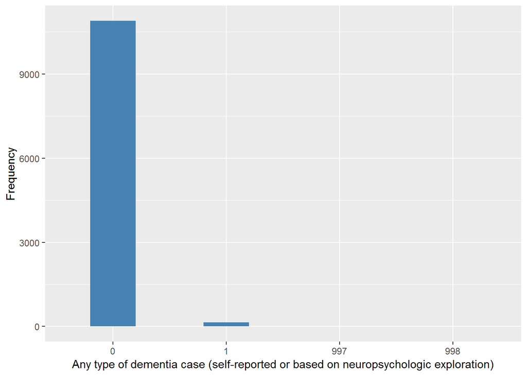

#### 2.1.4.4 Validation

### 2.1.5 Wave 5

#### 2.1.5.1 Study-specific variable description

| **Name** | `HeBdiaDE` |
| --- | --- |
| **Label** | `Wave when diagnosis of dementia or memory impairment was first reported` |
| **Table name** | `wave_5_elsa_data_v4` |
| **Categories** | `0 = Never reported` `1 = Wave 1` `2 = Wave 2` `3 = Wave 3` `4 = Wave 4` `5 = Wave 5` |
| **Missing** | `-9 = Refusal` `-8 = Don't know` |
| **Description** |  |

(en) (D) Wave when diagnosis of dementia or memory impairment was first reported

| Sample size | Missing values |
| --- | --- |
| 10274 | 0 |

Category

|  | -9 | -8 | 0 | 1 | 2 | 3 | 4 | 5 |
| --- | --- | --- | --- | --- | --- | --- | --- | --- |
| Frequency | 4.00 | 11.00 | 10088.00 | 16.00 | 8.00 | 19.00 | 49.00 | 79.00 |
| Percentage | 0.04 | 0.11 | 98.19 | 0.16 | 0.08 | 0.18 | 0.48 | 0.77 |

Type of missing

|  | -1 | -2 | -3 | NA |
| --- | --- | --- | --- | --- |
| Frequency | 0 | 0 | 0 | 0 |
| Percentage | 0 | 0 | 0 | 0 |

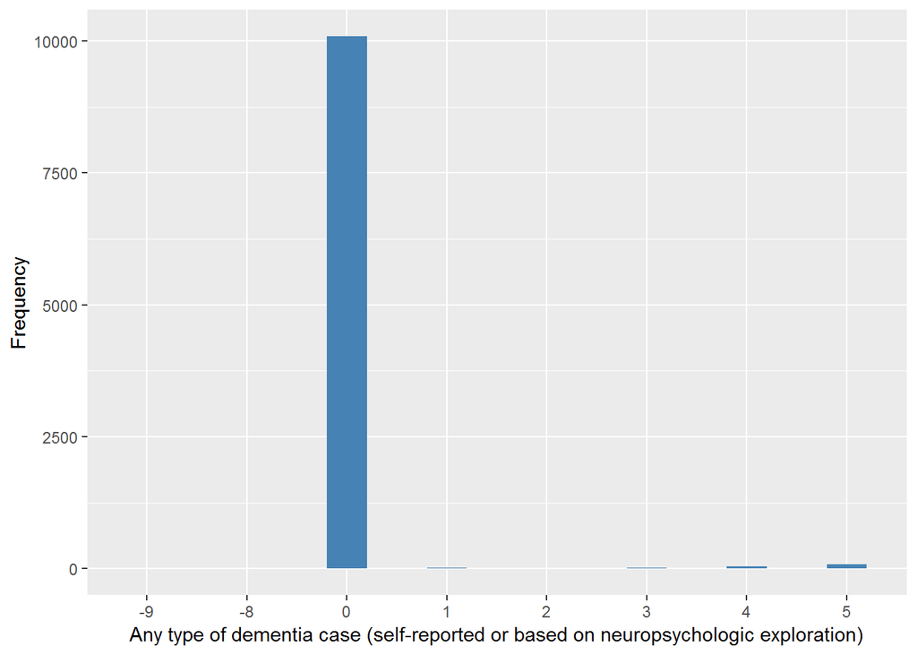

#### 2.1.5.2 Harmonisation algorithm

To compute the harmonized variable from the study-specific variable it has to be recoded as follows:

- `0 into 0`
- `1,2,3,4,5 into 1`
- `-8 into 998`
- `-9 into 997`

**R script:**

```r
ELSA_ds_w5 <- tibble(id = ELSA_dem$id)
ELSA_ds_w5$dementia <- car::recode(ELSA_dem[[2]], "2=1; 3=1; 4=1; 5=1; -8=998; -9=997")
```

#### 2.1.5.3 Statistical description of the new harmonised variable

Any type of dementia case (self-reported or based on neuropsychologic exploration)

| Sample size | Missing values |
| --- | --- |
| 10274 | 15 |

Category

|  | 0 | 1 |
| --- | --- | --- |
| Frequency | 10088.00 | 171.00 |
| Percentage | 98.19 | 1.66 |

Type of missing

|  | 991 | 992 | 993 | 994 | 995 | 996 | 997 | 998 | 999 | NA |
| --- | --- | --- | --- | --- | --- | --- | --- | --- | --- | --- |
| Frequency | 0 | 0 | 0 | 0 | 0 | 0 | 4.00 | 11.00 | 0 | 0 |
| Percentage | 0 | 0 | 0 | 0 | 0 | 0 | 0.04 | 0.11 | 0 | 0 |

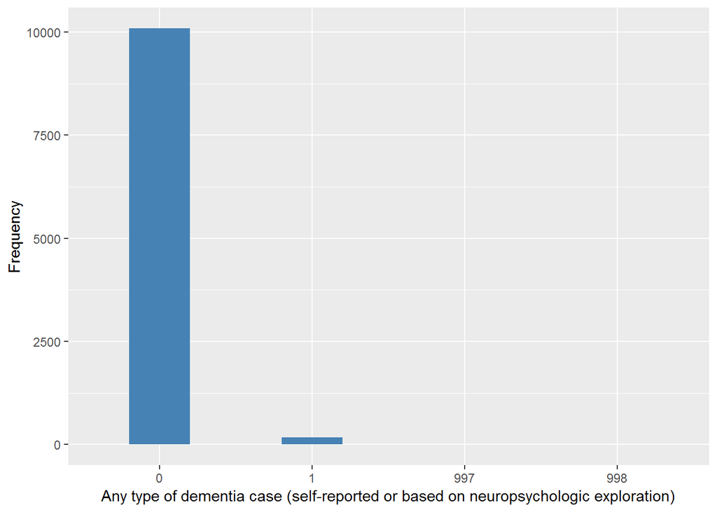

#### 2.1.5.4 Validation

### 2.1.6 Wave 6

#### 2.1.6.1 Study-specific variable description

| **Name** | `hedibde` |
| --- | --- |
| **Label** | `Chronic: dementia diagnosis newly reported` |
| **Table name** | `wave_6_elsa_data_v2` |
| **Categories** | `0 = Not mentioned` `1 = Mentioned` |
| **Missing** | `-9 = Refusal` `-8 = Don't Know` `-2 = Schedule not applicable` `-1 = Item not applicable` |
| **Description** |  |

(en) Chronic: dementia diagnosis newly reported

| Sample size | Missing values |
| --- | --- |
| 10601 | 0 |

Category

|  | -9 | -8 | 0 | 1 |
| --- | --- | --- | --- | --- |
| Frequency | 4.00 | 4.00 | 10481.00 | 112.00 |
| Percentage | 0.04 | 0.04 | 98.87 | 1.06 |

Type of missing

|  | -1 | -2 | -3 | NA |
| --- | --- | --- | --- | --- |
| Frequency | 0 | 0 | 0 | 0 |
| Percentage | 0 | 0 | 0 | 0 |

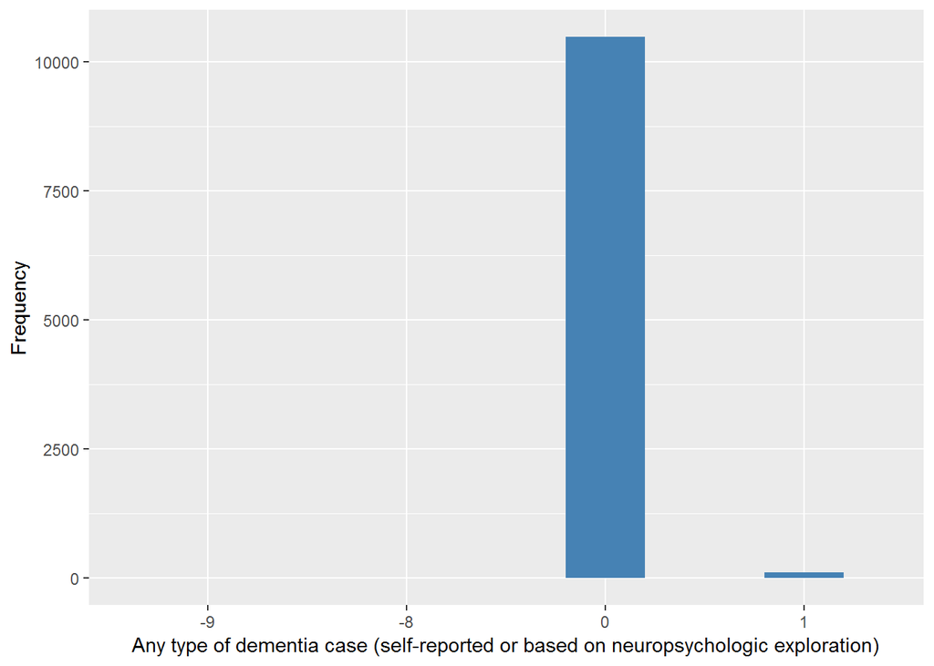

#### 2.1.6.2 Harmonisation algorithm

To compute the harmonized variable from the study-specific variable it has to be recoded as follows:

- `0 into 0`
- `1 into 1`
- `-8 into 998`
- `-9 into 997`
- `-2 into 996`
- `-1 into 996`

**R script:**

```r
ELSA_ds_w6 <- tibble(id = ELSA_dem$id)
ELSA_ds_w6$dementia <- car::recode(ELSA_dem[[2]], "-1=996; -2=996; -8=998; -9=997; NA=999")
```

#### 2.1.6.3 Statistical description of the new harmonised variable

Any type of dementia case (self-reported or based on neuropsychologic exploration)

| Sample size | Missing values |
| --- | --- |
| 10601 | 8 |

Category

|  | 0 | 1 |
| --- | --- | --- |
| Frequency | 10481.00 | 112.00 |
| Percentage | 98.87 | 1.06 |

Type of missing

|  | 991 | 992 | 993 | 994 | 995 | 996 | 997 | 998 | 999 | NA |
| --- | --- | --- | --- | --- | --- | --- | --- | --- | --- | --- |
| Frequency | 0 | 0 | 0 | 0 | 0 | 0 | 4.00 | 4.00 | 0 | 0 |
| Percentage | 0 | 0 | 0 | 0 | 0 | 0 | 0.04 | 0.04 | 0 | 0 |

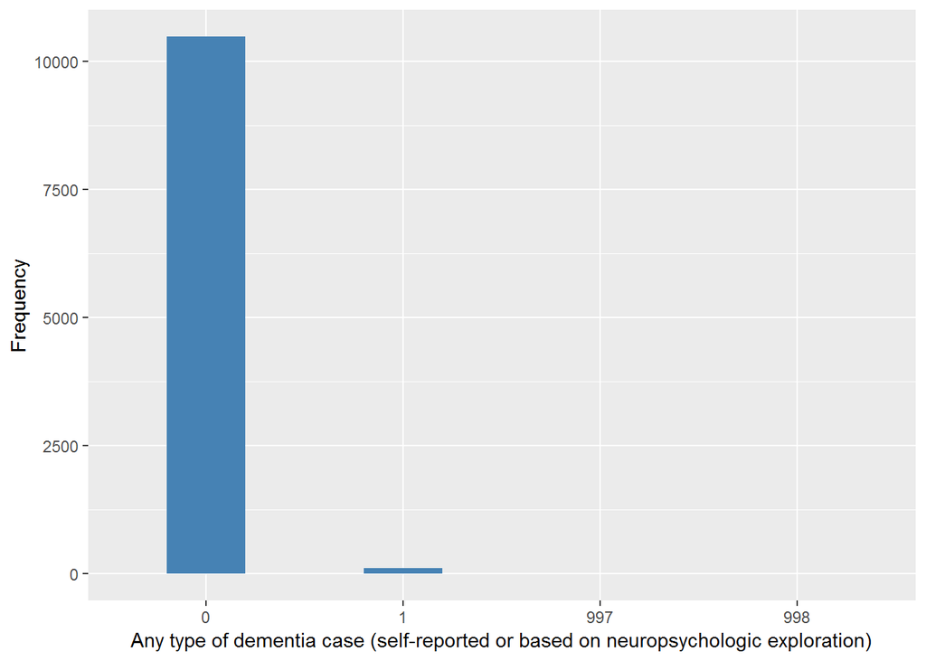

#### 2.1.6.4 Validation

### 2.1.7 Wave 7

#### 2.1.7.1 Study-specific variable description

| **Name** | `hedibde` |
| --- | --- |
| **Label** | `Chronic: dementia diagnosis newly reported` |
| **Table name** | `wave_7_elsa_data` |
| **Categories** | `0 = Not mentioned` `1 = Mentioned` |
| **Missing** | `-9 = Refusal` `-8 = Don't Know` `-2 = Schedule not applicable` `-1 = Item not applicable` |
| **Description** |  |

(en) Chronic: dementia diagnosis newly reported

| Sample size | Missing values |
| --- | --- |
| 9666 | 4 |

Category

|  | 0 | 1 |
| --- | --- | --- |
| Frequency | 9548.00 | 114.00 |
| Percentage | 98.78 | 1.18 |

Type of missing

|  | -1 | -2 | -8 | -9 | NA |
| --- | --- | --- | --- | --- | --- |
| Frequency | 0 | 0 | 4.00 | 0 | 0 |
| Percentage | 0 | 0 | 0.04 | 0 | 0 |

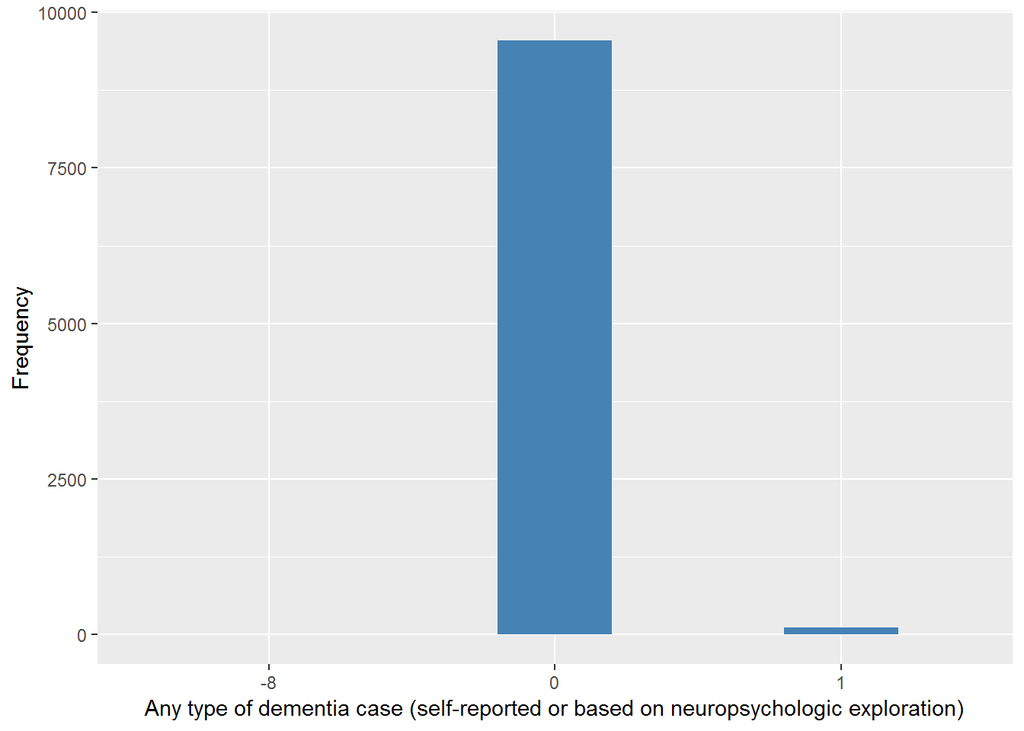

#### 2.1.7.2 Harmonisation algorithm

To compute the harmonized variable from the study-specific variable it has to be recoded as follows:

- `0 into 0`
- `1 into 1`
- `-8 into 998`
- `-9 into 997`
- `-2 into 996`
- `-1 into 996`

**R script:**

```r
ELSA_ds_w7 <- tibble(id = ELSA_dem$id)
ELSA_ds_w7$dementia <- car::recode(ELSA_dem[[2]], "-1=996; -2=996; -8=998; -9=997; NA=999")
```

#### 2.1.7.3 Statistical description of the new harmonised variable

Any type of dementia case (self-reported or based on neuropsychologic exploration)

| Sample size | Missing values |
| --- | --- |
| 9666 | 4 |

Category

|  | 0 | 1 |
| --- | --- | --- |
| Frequency | 9548.00 | 114.00 |
| Percentage | 98.78 | 1.18 |

Type of missing

|  | 991 | 992 | 993 | 994 | 995 | 996 | 997 | 998 | 999 | NA |
| --- | --- | --- | --- | --- | --- | --- | --- | --- | --- | --- |
| Frequency | 0 | 0 | 0 | 0 | 0 | 0 | 0 | 4.00 | 0 | 0 |
| Percentage | 0 | 0 | 0 | 0 | 0 | 0 | 0 | 0.04 | 0 | 0 |

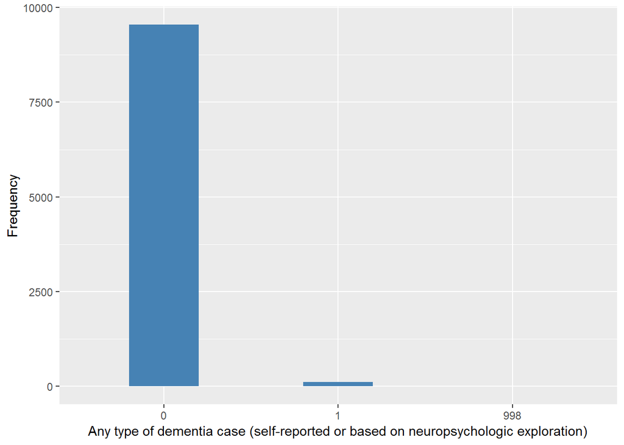

#### 2.1.7.4 Validation

# 3 Quality estimation

Two tables are generated:

1. Percentages of categories in each harmonised variable.
2. Frequencies and percentages of individuals with different trajectories. To avoid too large table, Only trajectories with percentages larger than 0.3 are shown.

```
##
##
## Table: Any type of dementia case (self-reported or based on neuropsychologic exploration)
##
## val   label                    W1      W2      W3      W4      W5      W6      W7
## ----  -----------------------  ------  ------  ------  ------  ------  ------  ------
## 0     no dementia              65.7    80.88   81.2    98.6    98.19   98.87   98.78
## 1     dementia                 0.22    0.54    1.15    1.29    1.66    1.06    1.18
## 991   CAPI interviewer error   0       0       0       0       0       0       0
## 992   Impute                   0       0       0       0       0       0       0
## 993   Disable to measure       0       0       0       0       0       0       0
## 994   Not attempt not done     0       0       0       0       0       0       0
## 995   Does not answer          0       0       0       0       0       0       0
## 996   Not applicable           0       0       0       0       0       0       0
## 997   Refuse                   0       0       0       0.05    0.04    0.04    0
```

[output cut: 34 more lines]

# 4 Quality estimation

No comments